# Medical Cost In USA

## Get dataset

```python
df=pd.read_csv('insurance.csv')
print_df(df.head())
```

|  | age | sex | bmi | children | smoker | region | charges |
| --- | --- | --- | --- | --- | --- | --- | --- |
| 0 | 19 | female | 27.9 | 0 | yes | southwest | 16884.9 |
| 1 | 18 | male | 33.77 | 1 | no | southeast | 1725.55 |
| 2 | 28 | male | 33 | 3 | no | southeast | 4449.46 |
| 3 | 33 | male | 22.705 | 0 | no | northwest | 21984.5 |
| 4 | 32 | male | 28.88 | 0 | no | northwest | 3866.86 |

- **bmi**: Body Mass Index ($kg / m ^ 2$)
- **charges**: Individual medical costs billed by health insurance
- **1338 rows**

## Exploring the data

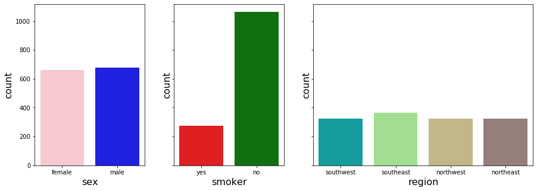

```python
f
```

From this, it seems that the dataset sample is representative of the US population:

- male and female equally represented
- 4 regions equally represented
- a majority of non smokers

## Exploring the data

```python
print_df(round(df.describe(),1))
```

|  | age | bmi | children | charges |
| --- | --- | --- | --- | --- |
| count | 1338 | 1338 | 1338 | 1338 |
| mean | 39.2 | 30.7 | 1.1 | 13270.4 |
| std | 14 | 6.1 | 1.2 | 12110 |
| min | 18 | 16 | 0 | 1121.9 |
| 25% | 27 | 26.3 | 0 | 4740.3 |
| 50% | 39 | 30.4 | 1 | 9382 |
| 75% | 51 | 34.7 | 2 | 16639.9 |
| max | 64 | 53.1 | 5 | 63770.4 |

- For age, bmi and number of children : $mean \simeq median $
- For charges : $mean > median $

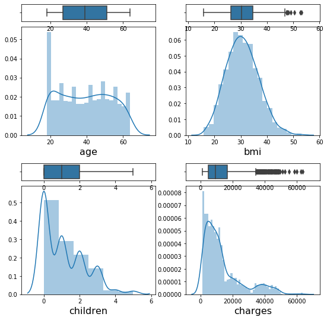

```python
fig
```

- For charges : $mean > median \Rightarrow$ a lot of outliers (high charges)

### Are there any correlations between numerical columns ?

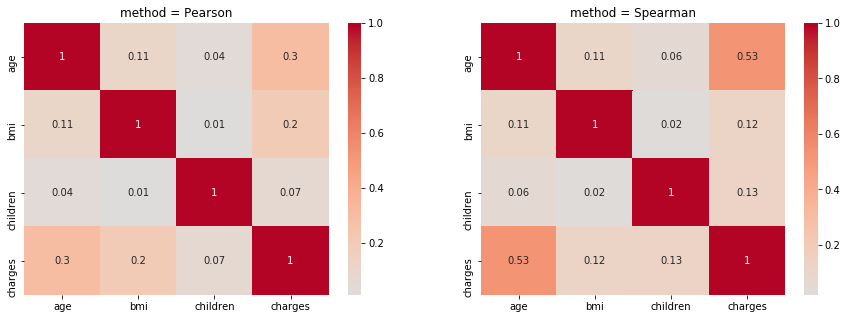

```python
f2
```

- Charges correlated with age ?
- Charges correlated with BMI ?

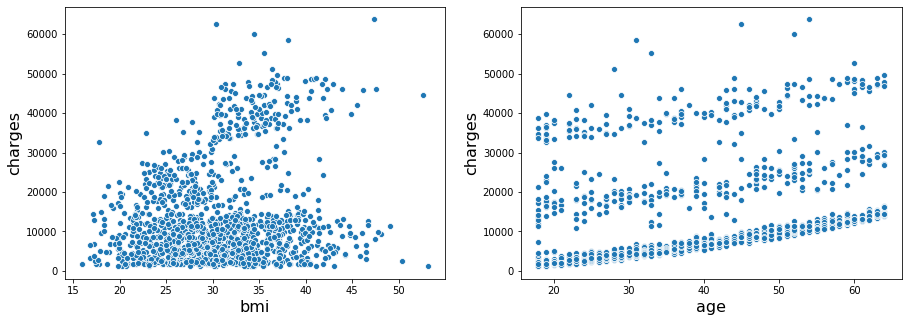

```python
f3
```

- In the charges=f(bmi) plot, there seem to be 2 groups on points (one with low charges, one with high charges)
- In the charges=f(age) plot, there seem to be 3 groups of points forming 3 lines with a positive slope

## Scraping BMI intervals depending on gender and age

[figure not shown]

```python
print_df(BMIs)
```

|  | age | male.optimal | male.acceptable | female.optimal | female.acceptable |
| --- | --- | --- | --- | --- | --- |
| 0 | [18.0, 34.0] | [23.0, 25.9] | [21.0, 28.9] | [15.5, 24.9] | [15.5, 25.9] |
| 1 | [35.0, 44.0] | [23.0, 26.9] | [22.0, 28.9] | [19.0, 23.9] | [17.5, 25.9] |
| 2 | [45.0, 49.0] | [24.0, 27.9] | [23.0, 28.9] | [20.0, 25.9] | [19.0, 26.9] |
| 3 | [50.0, 54.0] | [24.0, 27.9] | [23.0, 28.9] | [22.0, 26.9] | [21.0, 27.9] |
| 4 | [55.0, 64.0] | [24.0, 28.9] | [23.0, 31.4] | [23.0, 27.9] | [22.0, 29.9] |
| 5 | [65.0, 74.0] | [25.0, 28.9] | [23.0, 31.4] | [24.0, 28.9] | [22.0, 31.4] |
| 6 | [75.0, 99.0] | [25.0, 32.9] | [24.0, 34.9] | [24.0, 29.9] | [22.0, 36.4] |

# adding a column that gives BMI range

### (too low, optimal, acceptable, too high)

```python
print_df(df.sample(10))
```

|  | age | sex | bmi | children | smoker | region | charges | bmi_range |
| --- | --- | --- | --- | --- | --- | --- | --- | --- |
| 965 | 35 | male | 27.1 | 1 | no | southwest | 4746.34 | acceptable |
| 1153 | 35 | female | 35.815 | 1 | no | northwest | 5630.46 | too high |
| 426 | 38 | female | 27.265 | 1 | no | northeast | 6555.07 | too high |
| 198 | 51 | female | 18.05 | 0 | no | northwest | 9644.25 | too low |
| 1160 | 43 | female | 34.58 | 1 | no | northwest | 7727.25 | too high |
| 709 | 36 | female | 27.74 | 0 | no | northeast | 5469.01 | too high |
| 76 | 29 | female | 29.59 | 1 | no | southeast | 3947.41 | too high |
| 347 | 46 | male | 33.345 | 1 | no | northeast | 8334.46 | too high |
| 724 | 50 | female | 27.075 | 1 | no | northeast | 10106.1 | acceptable |
| 1196 | 19 | female | 30.02 | 0 | yes | northwest | 33307.6 | too high |

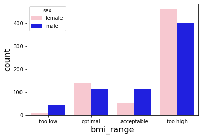

```python
fig2.figure
```

- A majority of the people in the sample have a too high BMI!

### Influence of smoking

```python
print_df(round(df.groupby(df.smoker).mean(),1))
```

| smoker | age | bmi | children | charges |
| --- | --- | --- | --- | --- |
| no | 39.4 | 30.7 | 1.1 | 8434.3 |
| yes | 38.5 | 30.7 | 1.1 | 32050.2 |

- Smokers are charged much more: smoking has negative effect on health!

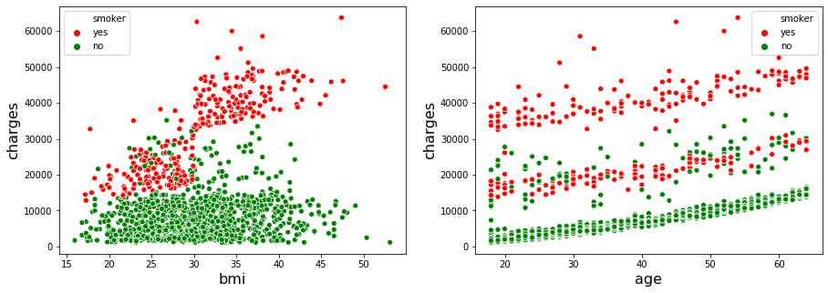

```python
fig3
```

- In the charges=f(bmi) plot, the 2 groups on points (one with low charges, one with high charges) can be explained by smokers/non smokers
- In the charges=f(age) plot, the 3 groups of points can be *partially* explained by smokers/non smokers

## Influence of BMI range ?

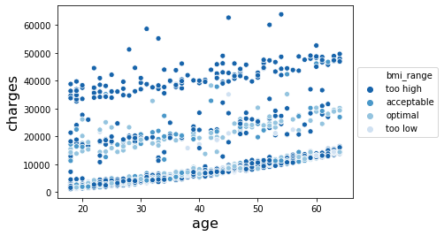

```python
fig4.figure
```

## Influence of smoking AND BMI

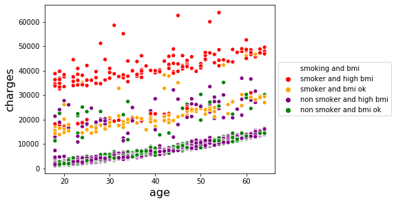

```python
fig5
```

In the charges=f(age) plot, the 3 groups of points can be explained by:

- low charges: non smokers (independant of BMI)
- medium charges: smokers with too low, optimal or acceptable BMI
- high charges: smokers with too high BMI